# Introducción general al uso de R Clase práctica 06

Autor/a

Afiliación

Ignacio Minoli  
`minolicnp@gmail.com`

Observatorio de Biodiversidad del Bosque Atlántico (OBBA) Instituto de Biología Subtropical (IBS) - Unidad Ejecutora del CONICET - UNaM

Fecha de publicación

29 de agosto de 2024

# 1 Expresiones condicionales

Es una construcción de programación con objetivos determinados en la que se toma la decisión de ejecutar algún código en función de una condición booleana (FALSE o TRUE) para alcanzar estos objetivos. En R las expresiones condicionales son importantes para la creación de funciones.

R utiliza más comúnmente: if (condición es un elemento), if - else (condición es un elemento), ifelse (condición es un vector) acompañado de operadores lógicos y de comparación.

- Operadores lógicos:
  - **&**: y, and
  - **|**: o, or
  - **!**: no, not
- Operadores de comparación:
  - **==**: igual, equal
  - **!=**: no igual, not equal
  - **<**: menor a, less than
  - **>**: mayor a, greater than
  - **>=**: mayor o igual a, greater than or equal
  - **<=**: menor o igual a, less than or equal

El flujo de funcionamiento es: si esta condición es verdadera, entonces haga esta operación; de lo contrario, haga esta operación diferente.

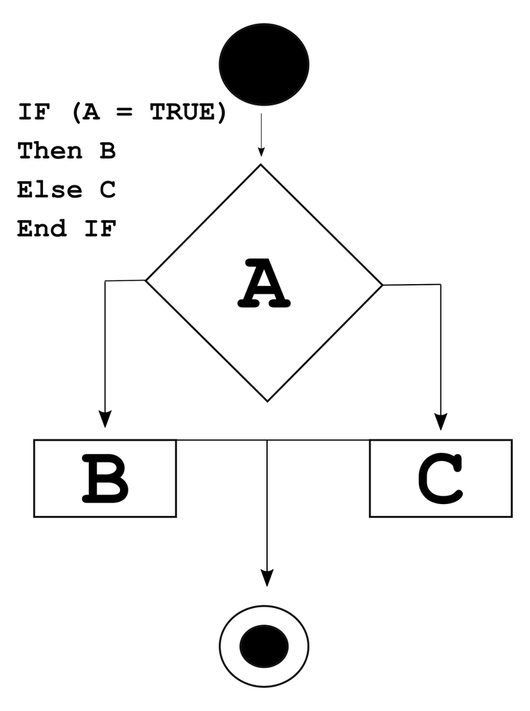

## 1.1 Crear una nueva variable con ifelse()

```r
library(palmerpenguins)
library(dplyr)

# Condicional para crear una nueva variable.
new_peng_1 <- penguins
glimpse(new_peng_1)
```

```
Rows: 344
Columns: 8
$ species           <fct> Adelie, Adelie, Adelie, Adelie, Adelie, Adelie, Adel…
$ island            <fct> Torgersen, Torgersen, Torgersen, Torgersen, Torgerse…
$ bill_length_mm    <dbl> 39.1, 39.5, 40.3, NA, 36.7, 39.3, 38.9, 39.2, 34.1, …
$ bill_depth_mm     <dbl> 18.7, 17.4, 18.0, NA, 19.3, 20.6, 17.8, 19.6, 18.1, …
$ flipper_length_mm <int> 181, 186, 195, NA, 193, 190, 181, 195, 193, 190, 186…
$ body_mass_g       <int> 3750, 3800, 3250, NA, 3450, 3650, 3625, 4675, 3475, …
$ sex               <fct> male, female, female, NA, female, male, female, male…
$ year              <int> 2007, 2007, 2007, 2007, 2007, 2007, 2007, 2007, 2007…
```

```r
# Variable masa_categ con 2 niveles de factor: "liviano" y "pesado"
new_peng_1$masa_categ <- ifelse(new_peng_1$body_mass_g < 3760,
                                "liviano", "pesado"
                                )
glimpse(new_peng_1)
```

```
Rows: 344
Columns: 9
$ species           <fct> Adelie, Adelie, Adelie, Adelie, Adelie, Adelie, Adel…
$ island            <fct> Torgersen, Torgersen, Torgersen, Torgersen, Torgerse…
$ bill_length_mm    <dbl> 39.1, 39.5, 40.3, NA, 36.7, 39.3, 38.9, 39.2, 34.1, …
$ bill_depth_mm     <dbl> 18.7, 17.4, 18.0, NA, 19.3, 20.6, 17.8, 19.6, 18.1, …
$ flipper_length_mm <int> 181, 186, 195, NA, 193, 190, 181, 195, 193, 190, 186…
$ body_mass_g       <int> 3750, 3800, 3250, NA, 3450, 3650, 3625, 4675, 3475, …
$ sex               <fct> male, female, female, NA, female, male, female, male…
$ year              <int> 2007, 2007, 2007, 2007, 2007, 2007, 2007, 2007, 2007…
$ masa_categ        <chr> "liviano", "pesado", "liviano", NA, "liviano", "livi…
```

## 1.2 Consulta rápida condicional

```r
library(palmerpenguins)
library(dplyr)

penguins[which(penguins$body_mass_g >= 6000), ]
```

```
# A tibble: 4 × 8
  species island bill_length_mm bill_depth_mm flipper_length_mm body_mass_g
  <fct>   <fct>           <dbl>         <dbl>             <int>       <int>
1 Gentoo  Biscoe           49.2          15.2               221        6300
2 Gentoo  Biscoe           59.6          17                 230        6050
3 Gentoo  Biscoe           51.1          16.3               220        6000
4 Gentoo  Biscoe           48.8          16.2               222        6000
# ℹ 2 more variables: sex <fct>, year <int>
```

## 1.3 Expresiones condicionales (tidyverse)

Permite hacer nuevas variables con expresiones más elaboradas. Ver ayuda de **case_when()**.

```r
library(palmerpenguins)
library(dplyr)

new_peng_2 <- penguins %>%
  mutate(masa_categ = case_when(
    body_mass_g < 3760 ~ "liviano",
    body_mass_g > 3760 ~ "pesado"
    )
)

glimpse(new_peng_2)
```

```
Rows: 344
Columns: 9
$ species           <fct> Adelie, Adelie, Adelie, Adelie, Adelie, Adelie, Adel…
$ island            <fct> Torgersen, Torgersen, Torgersen, Torgersen, Torgerse…
$ bill_length_mm    <dbl> 39.1, 39.5, 40.3, NA, 36.7, 39.3, 38.9, 39.2, 34.1, …
$ bill_depth_mm     <dbl> 18.7, 17.4, 18.0, NA, 19.3, 20.6, 17.8, 19.6, 18.1, …
$ flipper_length_mm <int> 181, 186, 195, NA, 193, 190, 181, 195, 193, 190, 186…
$ body_mass_g       <int> 3750, 3800, 3250, NA, 3450, 3650, 3625, 4675, 3475, …
$ sex               <fct> male, female, female, NA, female, male, female, male…
$ year              <int> 2007, 2007, 2007, 2007, 2007, 2007, 2007, 2007, 2007…
$ masa_categ        <chr> "liviano", "pesado", "liviano", NA, "liviano", "livi…
```

# 2 Loops en R

Son instrucciones replicadas para automatizar un proceso de múltiples pasos organizados en una secuencias de acciones. Hay dos tipos de loops, aquellos que iteran un cierto número de veces y aquellos que terminan al cumplirse una condición. El más usado y el que veremos aquí es el que se repite un número de veces **for loop**.

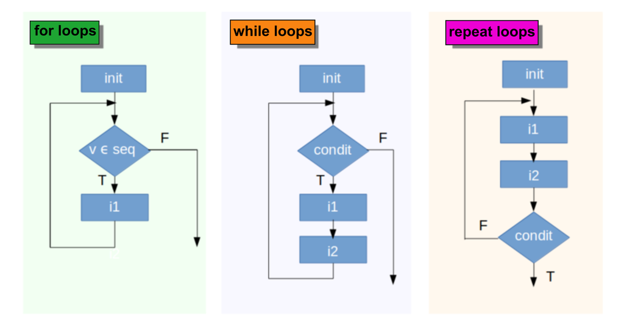

## 2.1 for loops

```r
# El loop comienza reemplazando i por 1 y va iterando hasta llegar al 5.
for (i in 1:5) {  # Rango del 1 al 5
print(i)          # Acción a realizar
}
```

```
[1] 1
[1] 2
[1] 3
[1] 4
[1] 5
```

```r
# El loop comienza reemplazando i por 1 y va iterando sumando 1 hasta
# llegar al 5.
for (i in 1:5) {
print(i + 1)
}
```

```
[1] 2
[1] 3
[1] 4
[1] 5
[1] 6
```

Ejemplo más complejo

```r
# Creo un data frame
tratamientos <- c("A", "B", "C", "D", "E", "F", "G", "H", "I", "J")
datos <- c(1, 2, 3, 4, 5, 6, 7, 8, 9, 10)

df <- data.frame(tratamientos, datos)
df
```

```
   tratamientos datos
1             A     1
2             B     2
3             C     3
4             D     4
5             E     5
6             F     6
7             G     7
8             H     8
9             I     9
10            J    10
```

```r
# Defino un vector a ser usado
df$datos
```

```
 [1]  1  2  3  4  5  6  7  8  9 10
```

```r
# El loop comienza reemplazando i por 1 y va iterando sumando 1 hasta
# llegar al 5.
for (i in seq(df$datos)) {
print(i * 2)
}
```

```
[1] 2
[1] 4
[1] 6
[1] 8
[1] 10
[1] 12
[1] 14
[1] 16
[1] 18
[1] 20
```

```r
# Lo asigno a un objeto nuevo para testear el loop
df_2 <- df

# Creo un nuevo vector que va a contener los resultados
datos_loop <- vector(mode = "numeric", length = length(df_2$datos))
datos_loop
```

```
 [1] 0 0 0 0 0 0 0 0 0 0
```

```r
# Analizar las lineas de este loop
for (i in 1:length(df_2$datos)) {
  result_loop <- (i * 2)
  datos_loop[i] <- result_loop
  df_3 <- cbind(df_2, datos_loop)
  }

# Dataframe original
df_2
```

```
   tratamientos datos
1             A     1
2             B     2
3             C     3
4             D     4
5             E     5
6             F     6
7             G     7
8             H     8
9             I     9
10            J    10
```

```r
# Dataframe con la variable nueva a partir del loop
df_3
```

```
   tratamientos datos datos_loop
1             A     1          2
2             B     2          4
3             C     3          6
4             D     4          8
5             E     5         10
6             F     6         12
7             G     7         14
8             H     8         16
9             I     9         18
10            J    10         20
```

```r
Ejercicio 06.1
1- Revisar la construcción y estructura del for loop e intentar crear una
variable nueva.
```

## 2.2 Loops sobre archivos

Utilizaremos un ejemplo reproducible.

```r
# Reviso cual es el directorio de trabajo
getwd()
```

```
[1] "D:/home/ignacio/Documents/IBS/Curso.R.Basico/2024/Clases.Practicas"
```

```r
# Descargo y descomprimo este archivo
download.file("http://www.datacarpentry.org/semester-biology/data/locations.zip",
              "locations.zip")
unzip("locations.zip")

# Investigamos que archivos hay en el directorio
list.files() %>%
  head(20)
```

```
 [1] "Clases.Practicas.Rproj"           "csv_missing_numbers.csv"
 [3] "df_1A.csv"                        "df_1C.csv"
 [5] "df_final.csv"                     "df_final2.csv"
 [7] "df1_tp3.csv"                      "df2_tp3.csv"
 [9] "df2_tp3_coordenadas.csv"          "Ejercicio_Final_.html"
[11] "Ejercicio_Final_.qmd"             "Ejercicio_Final_.Rmd"
[13] "Ejercicio_Final__files"           "Ejercicio_Final_RESULTADOS.html"
[15] "Ejercicio_Final_RESULTADOS.qmd"   "Ejercicio_Final_RESULTADOS.Rmd"
[17] "Ejercicio_Final_RESULTADOS_files" "Ejercicios_Resueltos_01.html"
[19] "Ejercicios_Resueltos_01.qmd"      "Ejercicios_Resueltos_02.html"
```

```r
# Me interesan solo los que comienzan con "locations-"
data_files <- list.files(pattern = "locations-*", full.names = TRUE)
data_files
```

```
[1] "./locations-2016-01-01.txt" "./locations-2016-01-02.txt"
[3] "./locations-2016-01-03.txt" "./locations-2016-01-04.txt"
[5] "./locations-2016-01-05.txt" "./locations.zip"
```

Ahora podemos hacer un loop para contar el nro de observaciones por archivo

```r
library(tidyverse)

## Preparo los set de datos
data_files
```

```
[1] "./locations-2016-01-01.txt" "./locations-2016-01-02.txt"
[3] "./locations-2016-01-03.txt" "./locations-2016-01-04.txt"
[5] "./locations-2016-01-05.txt" "./locations.zip"
```

```r
# Saco el .zip
data_files_bis <- data_files[-c(6)]
data_files_bis
```

```
[1] "./locations-2016-01-01.txt" "./locations-2016-01-02.txt"
[3] "./locations-2016-01-03.txt" "./locations-2016-01-04.txt"
[5] "./locations-2016-01-05.txt"
```

```r
# Vector vacio
results <- vector(mode = "integer", length = length(data_files_bis))
results
```

```
[1] 0 0 0 0 0
```

```r
# Loop

# Iteración de 1 a 5, que son los archivos
for (i in 1:length(data_files_bis)){
  # Función para una acción leer cada .txt
  data <- read.csv(data_files_bis[i])
  # Funciones para una acción. Da el nro de filas
  count <- nrow(data)
  # Asigna los resultados a un objeto
  results[i] <- count
}

# Reviso los vectores
data_files_bis
```

```
[1] "./locations-2016-01-01.txt" "./locations-2016-01-02.txt"
[3] "./locations-2016-01-03.txt" "./locations-2016-01-04.txt"
[5] "./locations-2016-01-05.txt"
```

```r
results
```

```
[1]  4  8 10 10 12
```

```r
# Creo un tibble o dataframe con los vectores
final <- tibble(
  file = data_files_bis,
  num_rows = results
  ) %>%
  # Saco "./locations-" de la variable file
  mutate(file = str_replace_all(
    file,
    "./locations-",
    ""
    )
    )
final
```

```
# A tibble: 5 × 2
  file           num_rows
  <chr>             <int>
1 2016-01-01.txt        4
2 2016-01-02.txt        8
3 2016-01-03.txt       10
4 2016-01-04.txt       10
5 2016-01-05.txt       12
```

```r
Ejercicio 06.2
1- Abrir los archivos de texto usando browseURL() y revisar si el loop fue exitoso en su tarea.
2- ¿Qué otros tipos de "tareas" se te ocurren con archivos?
```

# 3 Función en R

Son la pieza fundamental del lenguaje R.

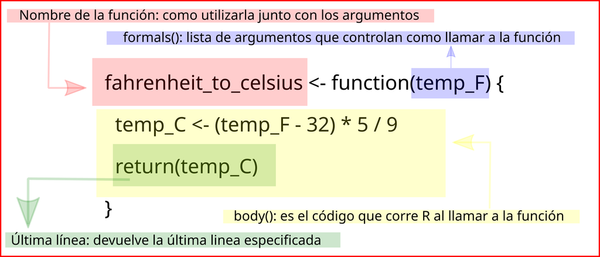

Se pueden modificar las funciones ya creadas para agregar o cambiar argumentos o incluso crear funciones totalmente nuevas para una tarea específica.

```r
# Función para transformar grados Fahrenheit a Celsius
fahrenheit_to_celsius_2 <- function(temp_F) {
  temp_C <- (temp_F - 32) * 5 / 9
  return(round(temp_C, 2)) # Si no uso return no se ven los resultados
}

library(tidyverse)

# Creo un data frame de ejemplo
df_temps <- data.frame(grados_F = c(50, 202, 85, 76),
                       trat = c("Testigo", "Alcalino", "Acido", "Neutro")
                       )
df_temps
```

```
  grados_F     trat
1       50  Testigo
2      202 Alcalino
3       85    Acido
4       76   Neutro
```

```r
# Corro la función sobre el vector
fahrenheit_to_celsius_2(df_temps$grados_F)
```

```
[1] 10.00 94.44 29.44 24.44
```

Ejemplo de una función creando una variable nueva y re diseñando el data frame:

```r
# Copia del data frame
df_temps_2 <- df_temps
df_temps_2
```

```
  grados_F     trat
1       50  Testigo
2      202 Alcalino
3       85    Acido
4       76   Neutro
```

```r
# Defino la función
fahrenheit_to_celsius_3 <- function(temp_F) {
  new_df <- subset(temp_F)[1] # Hago un subset creando un nuevo df
  names(new_df)[1] <- "grados_C" # Le doy un nombre a la columna
  temp_C <- (new_df - 32) * 5 / 9 # Hago la conversión de grados
  cbind(temp_F, round(temp_C, 2)) # Uno las cols df orginal y nuevo df
  }

# Corro la función
df_temps_3 <- fahrenheit_to_celsius_3(df_temps_2)

# Veo el resultado de la función
df_temps_3
```

```
  grados_F     trat grados_C
1       50  Testigo    10.00
2      202 Alcalino    94.44
3       85    Acido    29.44
4       76   Neutro    24.44
```

```r
Ejercicio 06.3
1- Crear un data frame de 2 columnas variables y una de ellas con valores  numéricos en pulgadas.
2- Crear una función para crear una variable nueva en centímetros a partir de la transformación de los valores de pulgadas y unirlos en el mismo data frame.
```

# 4 Familia funciones: apply

Es una alternativa a las funciones. Tienen el beneficio de ser muy rápidas y fáciles de usar. Esta familia de funciones siempre invocan otra función que se repite a lo largo de e.g., un vector. La familia de funciones apply está formada por:

- **apply()**: opera en arrays
- **lapply()**: usada en data frames o listas de vectores
- **tapply()**: permite crear resúmenes de factores de nivel
- **sapply()**: es una versión resumida de lapply()
- **vapply()**: es similar a sapply() pero hay que especificar formato de salida
- **mapply()**: diseñada para utilizar apply() de manera multivariada

Personalmente, las utilizo hasta para cargar varios paquetes en simultáneo y ahorrar espacio o lineas de código.

```r
# sapply para cargar múltiples paquetes de una sola vez
packages <- c("magrittr", "dplyr", "sf", "tidyverse")
sapply(packages, require, character.only=T)
```

```
 magrittr     dplyr        sf tidyverse
     TRUE      TRUE      TRUE      TRUE
```

```r
# Es equivalente a:
library(magrittr)
library(dplyr)
library(sf)
library(tidyverse)
```

Ejemplo de **apply()**

```r
# Creando un data frame
df <- data.frame(x = 1:4, y = 5:8, z = 10:13)
df
```

```
  x y  z
1 1 5 10
2 2 6 11
3 3 7 12
4 4 8 13
```

```r
# Suma por filas CON los argumentos definidos
apply(X = df, MARGIN = 1, FUN = sum)
```

```
[1] 16 19 22 25
```

```r
# Suma por filas SIN los argumentos definidos
apply(df, 1, sum)
```

```
[1] 16 19 22 25
```

```r
# Suma por filas solo filas 1 y 2
apply(df[c(1, 2), ], 1, sum)
```

```
 1  2
16 19
```

```r
# Suma por columnas MARGIN = 2
apply(df, 2, sum)
```

```
 x  y  z
10 26 46
```

```r
# Suma por columnas 1 y 3
apply(df[, c(1, 3)], 2, sum)
```

```
 x  z
10 46
```

Si defino una función propia podría reemplazar el argumento FUN de **apply()** y así utilizar esa función propia.